# Electric Vehicles data analysis

Xinzhao You

https://xinzhaoy.github.io/cmps6790_project/

### Introduction:

Interest in electric vehicles (EVs) is growing. To gain a comprehensive understanding of the electric vehicle landscape, I aimed to explore three key data sets using Washington state as an example: electric vehicle ownership data, population statistics, and EV charging stations.

### Datasets

- Dataset 1: [Electric Vehicle Population Data](https://data.wa.gov/Transportation/Electric-Vehicle-Population-Data/f6w7-q2d2)

  This dataset shows the Battery Electric Vehicles (BEVs) and Plug-in Hybrid Electric Vehicles (PHEVs) that are currently registered through Washington State Department of Licensing (DOL).
- Dataset 2: [USA Census Income Data](https://www.kaggle.com/datasets/manishkc06/usa-census-income-data/data)

  This dataset can give me Total income amount, Salaries and wages amount
- Dataset 3: [Alternative Fueling Stations from U.S. Department of Transportation](https://data-usdot.opendata.arcgis.com/datasets/usdot::alternative-fueling-stations/about)

  This dataset can give me the number of EV station in the arae.

### Question

```
    1: Are there discernible regional trends or hotspots for EV population?
    2: How is the level of income related to the likelihood of owning an electric vehicle?
    3: Consider your income as an employee, can we get an recommendation that should you buy a EV?
```

### Collaboration Plan

There is no collaboration plan because this is a solo project

### Extraction, Transform, and Load (ETL)

```python
# Import libraries
import pandas as pd
import numpy as np
import matplotlib.pyplot as plt
import seaborn as sns
from sklearn.model_selection import train_test_split
from sklearn.linear_model import LinearRegression
from sklearn.model_selection import cross_val_score
from sklearn.preprocessing import StandardScaler
from sklearn.metrics import make_scorer, mean_absolute_error
from sklearn.metrics import r2_score
from sklearn.cluster import KMeans
from sklearn.preprocessing import StandardScaler
from scipy.optimize import curve_fit
```

**Dataset 1: Electric Vehicle Population Data**

```python
# Read csv file
file_path = '../Data/Electric_Vehicle_Population_Data_20231107.csv'

ev_table = pd.read_csv(file_path, dtype='str', low_memory=False)
```

```python
# Extract the ev_table
ev_table.head()
```

|  | VIN (1-10) | County | City | State | Postal Code | Model Year | Make | Model | Electric Vehicle Type | Clean Alternative Fuel Vehicle (CAFV) Eligibility | Electric Range | Base MSRP | Legislative District | DOL Vehicle ID | Vehicle Location | Electric Utility | 2020 Census Tract |
| --- | --- | --- | --- | --- | --- | --- | --- | --- | --- | --- | --- | --- | --- | --- | --- | --- | --- |
| 0 | 5UXTA6C05P | Yakima | Yakima | WA | 98903 | 2023 | BMW | X5 | Plug-in Hybrid Electric Vehicle (PHEV) | Clean Alternative Fuel Vehicle Eligible | 30 | 0 | 14 | 227153587 | POINT (-120.477805 46.553505) | PACIFICORP | 53077002803 |
| 1 | 5YJRE11B48 | NaN | NaN | BC | NaN | 2008 | TESLA | ROADSTER | Battery Electric Vehicle (BEV) | Clean Alternative Fuel Vehicle Eligible | 220 | 98,950 | NaN | 143609049 | NaN | NaN | NaN |
| 2 | 5YJSA1E24G | King | Seattle | WA | 98103 | 2016 | TESLA | MODEL S | Battery Electric Vehicle (BEV) | Clean Alternative Fuel Vehicle Eligible | 210 | 0 | 43 | 187728201 | POINT (-122.34301 47.659185) | CITY OF SEATTLE - (WA)\|CITY OF TACOMA - (WA) | 53033004902 |
| 3 | 1N4AZ1CP5J | King | Shoreline | WA | 98177 | 2018 | NISSAN | LEAF | Battery Electric Vehicle (BEV) | Clean Alternative Fuel Vehicle Eligible | 151 | 0 | 32 | 249867971 | POINT (-122.382425 47.77279) | CITY OF SEATTLE - (WA)\|CITY OF TACOMA - (WA) | 53033020100 |
| 4 | 5YJ3E1EA6J | Island | Coupeville | WA | 98239 | 2018 | TESLA | MODEL 3 | Battery Electric Vehicle (BEV) | Clean Alternative Fuel Vehicle Eligible | 215 | 0 | 10 | 223792649 | POINT (-122.6880708 48.2179983) | PUGET SOUND ENERGY INC | 53029971100 |

As shown in this table, I can see there is some other state information. Now, I need to filter the data for the state of Washington (WA).

```python
# Filter the DataFrame to include only rows where the 'State' column is 'WA'
ev_table = ev_table[ev_table['State'] == 'WA']
```

```python
# Drop some unneeded data
columns_to_drop = ['VIN (1-10)', 'DOL Vehicle ID', 'Vehicle Location',
                   '2020 Census Tract', 'Legislative District', 'Base MSRP', 'Electric Utility']
ev_table = ev_table.drop(columns=columns_to_drop)
```

```python
ev_table.head()
```

|  | County | City | State | Postal Code | Model Year | Make | Model | Electric Vehicle Type | Clean Alternative Fuel Vehicle (CAFV) Eligibility | Electric Range |
| --- | --- | --- | --- | --- | --- | --- | --- | --- | --- | --- |
| 0 | Yakima | Yakima | WA | 98903 | 2023 | BMW | X5 | Plug-in Hybrid Electric Vehicle (PHEV) | Clean Alternative Fuel Vehicle Eligible | 30 |
| 2 | King | Seattle | WA | 98103 | 2016 | TESLA | MODEL S | Battery Electric Vehicle (BEV) | Clean Alternative Fuel Vehicle Eligible | 210 |
| 3 | King | Shoreline | WA | 98177 | 2018 | NISSAN | LEAF | Battery Electric Vehicle (BEV) | Clean Alternative Fuel Vehicle Eligible | 151 |
| 4 | Island | Coupeville | WA | 98239 | 2018 | TESLA | MODEL 3 | Battery Electric Vehicle (BEV) | Clean Alternative Fuel Vehicle Eligible | 215 |
| 5 | Kitsap | Seabeck | WA | 98380 | 2017 | CHEVROLET | BOLT EV | Battery Electric Vehicle (BEV) | Clean Alternative Fuel Vehicle Eligible | 238 |

```python
# Read csv file
file_path = '../Data/Alternative_Fueling_Stations.csv'

station = pd.read_csv(file_path, dtype='str', low_memory=False)

station.head()
```

|  | X | Y | OBJECTID | access_code | access_days_time | access_detail_code | cards_accepted | date_last_confirmed | expected_date | fuel_type_code | ... | bd_blends_fr | groups_with_access_code_fr | ev_pricing_fr | federal_agency_id | federal_agency_code | federal_agency_name | ev_network_ids_station | ev_network_ids_posts | longitude | latitude |
| --- | --- | --- | --- | --- | --- | --- | --- | --- | --- | --- | --- | --- | --- | --- | --- | --- | --- | --- | --- | --- | --- |
| 0 | -86.267021 | 32.367916 | 1 | private | NaN | NaN | NaN | 2023/04/06 00:00:00+00 | NaN | CNG | ... | NaN | Privé | NaN | NaN | NaN | NaN | NaN | NaN | -86.267021 | 32.367916 |
| 1 | -84.367461 | 33.821911 | 2 | private | NaN | GOVERNMENT | NaN | 2023/01/10 00:00:00+00 | NaN | CNG | ... | NaN | Privé - Réservé au gouvernement | NaN | NaN | NaN | NaN | NaN | NaN | -84.367461 | 33.821911 |
| 2 | -84.543822 | 33.760256 | 3 | private | NaN | NaN | NaN | 2022/06/14 00:00:00+00 | NaN | CNG | ... | NaN | Privé | NaN | NaN | NaN | NaN | NaN | NaN | -84.543822 | 33.760256 |
| 3 | -94.375338 | 35.362213 | 4 | public | 24 hours daily | CREDIT_CARD_ALWAYS | FuelMan M V Wright_Exp | 2023/08/10 00:00:00+00 | NaN | CNG | ... | NaN | Public - Carte de crédit en tout temps | NaN | NaN | NaN | NaN | NaN | NaN | -94.375338 | 35.362213 |
| 4 | -71.02654861 | 42.37470555 | 5 | public | 24 hours daily; call 866-809-4869 for Clean En... | CREDIT_CARD_ALWAYS | A CleanEnergy Comdata D FuelMan M V Voyager Wr... | 2023/09/14 00:00:00+00 | NaN | CNG | ... | NaN | Public - Carte de crédit en tout temps | NaN | NaN | NaN | NaN | NaN | NaN | -71.02654861 | 42.37470555 |

5 rows × 79 columns

This table includes more information than necessary for my project. Therefore, my next step will be to retain the relevant information and discard the unnecessary details.

```python
# read csv file to Court Directory: County-City Reference List
file_path = '../Data/uscities.csv'
city_county = pd.read_csv(file_path, dtype='str', low_memory=False)
city_county = city_county.loc[city_county['state_id'].str.contains('WA', na=False)]
```

```python
# Drop some unneeded data
columns_to_drop = ['city_ascii', 'county_fips', 'lat', 'lng', 'population', 'density', 'source', 'military',
                   'incorporated', 'timezone', 'ranking', 'zips', 'id']
city_county.drop(columns = columns_to_drop, inplace = True)
```

```python
# Drop some unneeded data
columns_to_drop = ['X', 'Y', 'OBJECTID', 'access_code', 'access_days_time',
       'access_detail_code', 'cards_accepted', 'date_last_confirmed',
       'expected_date','groups_with_access_code', 'id',
       'open_date', 'owner_type_code', 'status_code', 'restricted_access',
       'maximum_vehicle_class', 'station_phone', 'updated_at',
       'facility_type', 'geocode_status', 'intersection_directions',
       'plus4', 'bd_blends', 'country',
       'cng_dispenser_num', 'cng_fill_type_code', 'cng_psi',
       'cng_renewable_source', 'cng_total_compression', 'cng_total_storage',
       'cng_vehicle_class', 'cng_has_rng', 'e85_blender_pump',
       'e85_other_ethanol_blends', 'ev_connector_types', 'ev_dc_fast_num',
       'ev_level1_evse_num', 'ev_level2_evse_num', 'ev_network',
       'ev_network_web', 'ev_other_evse', 'ev_pricing', 'ev_renewable_source',
       'ev_workplace_charging', 'hy_is_retail', 'hy_pressures', 'hy_standards',
       'hy_status_link', 'lng_renewable_source', 'lng_vehicle_class',
       'lng_has_rng', 'lpg_primary', 'lpg_nozzle_types', 'ng_fill_type_code',
       'ng_psi', 'ng_vehicle_class', 'rd_blends', 'rd_blends_fr',
       'rd_blended_with_biodiesel', 'rd_max_biodiesel_level', 'nps_unit_name',
       'access_days_time_fr', 'intersection_directions_fr', 'bd_blends_fr',
       'groups_with_access_code_fr', 'ev_pricing_fr', 'federal_agency_id',
       'federal_agency_code', 'federal_agency_name', 'ev_network_ids_station',
       'ev_network_ids_posts', 'longitude', 'latitude']
station.drop(columns = columns_to_drop, inplace = True)
```

```python
# merge two table and match county for each city
station = station.merge(city_county, how='inner', on=['city','city'])
# Drop some unneeded data after merge
columns_to_drop = ['state_id', 'state_name']
station.drop(columns = columns_to_drop, inplace = True)
# Rename columns and reorder
station = station.rename(columns={'county_name': 'county'})
column_order = ['fuel_type_code', 'station_name', 'street_address', 'city', 'county', 'state','zip']
station = station[column_order]
```

```python
# Get elec station and state of WA
ev_station = station.loc[(station['fuel_type_code'].str.contains('ELEC')) & (station['state'].str.contains('WA', na=False))]

ev_station.head()
```

|  | fuel_type_code | station_name | street_address | city | county | state | zip |
| --- | --- | --- | --- | --- | --- | --- | --- |
| 2 | ELEC | Campbell Nissan - Everett | 10500 Highway 99 S | Everett | Snohomish | WA | 98204 |
| 5 | ELEC | Kia of Everett | 229 SW Everett Mall Way | Everett | Snohomish | WA | 98204 |
| 7 | ELEC | Naval Facilities Engineering Command - Naval S... | 2000 W Marine View Dr | Everett | Snohomish | WA | 98207 |
| 8 | ELEC | Naval Facilities Engineering Command - Naval S... | 2000 W Marine View Dr | Everett | Snohomish | WA | 98207 |
| 9 | ELEC | Walmart 3053 - Everett, WA | 1605 SE Everett Mall Way | Everett | Snohomish | WA | 98208 |

```python
# read csv file
file_path = '../Data/acs2017_county_data.csv'
Demographic = pd.read_csv(file_path, dtype='str', low_memory=False)

Demographic.head()
```

|  | CountyId | State | County | TotalPop | Men | Women | Hispanic | White | Black | Native | ... | Walk | OtherTransp | WorkAtHome | MeanCommute | Employed | PrivateWork | PublicWork | SelfEmployed | FamilyWork | Unemployment |
| --- | --- | --- | --- | --- | --- | --- | --- | --- | --- | --- | --- | --- | --- | --- | --- | --- | --- | --- | --- | --- | --- |
| 0 | 1001 | Alabama | Autauga County | 55036 | 26899 | 28137 | 2.7 | 75.4 | 18.9 | 0.3 | ... | 0.6 | 1.3 | 2.5 | 25.8 | 24112 | 74.1 | 20.2 | 5.6 | 0.1 | 5.2 |
| 1 | 1003 | Alabama | Baldwin County | 203360 | 99527 | 103833 | 4.4 | 83.1 | 9.5 | 0.8 | ... | 0.8 | 1.1 | 5.6 | 27.0 | 89527 | 80.7 | 12.9 | 6.3 | 0.1 | 5.5 |
| 2 | 1005 | Alabama | Barbour County | 26201 | 13976 | 12225 | 4.2 | 45.7 | 47.8 | 0.2 | ... | 2.2 | 1.7 | 1.3 | 23.4 | 8878 | 74.1 | 19.1 | 6.5 | 0.3 | 12.4 |
| 3 | 1007 | Alabama | Bibb County | 22580 | 12251 | 10329 | 2.4 | 74.6 | 22.0 | 0.4 | ... | 0.3 | 1.7 | 1.5 | 30.0 | 8171 | 76.0 | 17.4 | 6.3 | 0.3 | 8.2 |
| 4 | 1009 | Alabama | Blount County | 57667 | 28490 | 29177 | 9.0 | 87.4 | 1.5 | 0.3 | ... | 0.4 | 0.4 | 2.1 | 35.0 | 21380 | 83.9 | 11.9 | 4.0 | 0.1 | 4.9 |

5 rows × 37 columns

This table contains information from various states, which I do not need. My next step will be to keep only the data pertaining to the state of Washington.

```python
# Filter the DataFrame to include only rows where the 'State' column is 'Washington'
Demographic = Demographic[Demographic['State'] == 'Washington']

# Drop the 'State' column
columns_to_drop = ['State', 'VotingAgeCitizen', 'IncomeErr',
                               'IncomePerCap', 'IncomePerCapErr', 'Poverty',
                               'ChildPoverty','Service', 'Office', 'Construction',
                                'Production', 'Drive', 'Carpool', 'Transit', 'Walk', 'OtherTransp',
                                'WorkAtHome', 'MeanCommute']

Demographic = Demographic.drop(columns=columns_to_drop)
# Remove 'County' from the 'County' column
Demographic['County'] = Demographic['County'].str.replace(' County', '')

Demographic.head()
```

|  | CountyId | County | TotalPop | Men | Women | Hispanic | White | Black | Native | Asian | Pacific | Income | Professional | Employed | PrivateWork | PublicWork | SelfEmployed | FamilyWork | Unemployment |
| --- | --- | --- | --- | --- | --- | --- | --- | --- | --- | --- | --- | --- | --- | --- | --- | --- | --- | --- | --- |
| 2953 | 53001 | Adams | 19261 | 9750 | 9511 | 62.3 | 35.2 | 0.3 | 0.4 | 1.0 | 0.0 | 48131 | 22.8 | 7757 | 81.2 | 14.6 | 3.8 | 0.3 | 5.9 |
| 2954 | 53003 | Asotin | 22259 | 10594 | 11665 | 3.6 | 91.2 | 0.4 | 0.9 | 0.9 | 0.1 | 47483 | 30.0 | 9824 | 78.6 | 16.1 | 5.2 | 0.1 | 6.7 |
| 2955 | 53005 | Benton | 190529 | 95438 | 95091 | 20.8 | 71.6 | 1.4 | 0.6 | 2.5 | 0.1 | 63001 | 39.4 | 85352 | 78.4 | 17.3 | 4.3 | 0.1 | 6.0 |
| 2956 | 53007 | Chelan | 75138 | 37352 | 37786 | 27.5 | 68.3 | 0.4 | 0.9 | 0.9 | 0.1 | 54975 | 30.4 | 34063 | 76.2 | 16.2 | 7.4 | 0.2 | 5.8 |
| 2957 | 53009 | Clallam | 73439 | 36389 | 37050 | 6.0 | 83.3 | 1.1 | 4.4 | 1.5 | 0.1 | 48002 | 30.2 | 28027 | 68.4 | 22.9 | 8.6 | 0.2 | 8.8 |

Checking Data types.

```python
# Display data types for each tables
print('Data type of EV table ', ev_table.dtypes)
print('Data type of EV station ', ev_station.dtypes)
print('Data type of Demographic ',Demographic.dtypes)
```

```
Data type of EV table  County                                               object
City                                                 object
State                                                object
Postal Code                                          object
Model Year                                           object
Make                                                 object
Model                                                object
Electric Vehicle Type                                object
Clean Alternative Fuel Vehicle (CAFV) Eligibility    object
Electric Range                                       object
dtype: object
Data type of EV station  fuel_type_code    object
station_name      object
street_address    object
city              object
county            object
state             object
zip               object
dtype: object
Data type of Demographic  CountyId        object
County          object
TotalPop        object
Men             object
Women           object
Hispanic        object
White           object
Black           object
Native          object
Asian           object
Pacific         object
Income          object
Professional    object
Employed        object
PrivateWork     object
PublicWork      object
SelfEmployed    object
FamilyWork      object
Unemployment    object
dtype: object
```

### Exploratory Data Analysis (EDA)

In the Exploratory Data Analysis (EDA) section, I will visualize the data from each table to facilitate future analysis.

```python
# Vehcle Count by year
# Convert 'Model Year' to an integer
ev_table['Model Year'] = pd.to_numeric(ev_table['Model Year'], errors='coerce')

# Drop rows with NaN values in 'Model Year' if any were created during conversion
ev_table = ev_table.dropna(subset=['Model Year'])

# Convert 'Model Year' to integers
ev_table['Model Year'] = ev_table['Model Year'].astype(int)

# Filter out rows where the 'Model Year' is 2024
ev_table = ev_table[ev_table['Model Year'] != 2024]

# Aggregate data by year
ev_by_year = ev_table.groupby('Model Year').size().reset_index(name='electric_vehicle_count')
# Drop NaN values that may have resulted from conversion errors
ev_table.dropna(subset=['Model Year'], inplace=True)
```

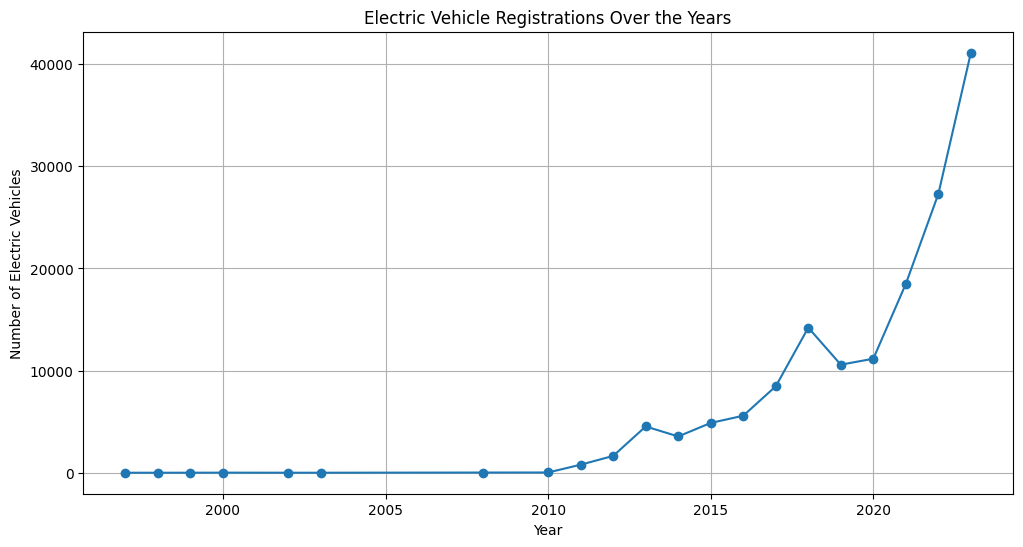

```python
# Line chart for overall trend
plt.figure(figsize=(12, 6))
plt.plot(ev_by_year['Model Year'], ev_by_year['electric_vehicle_count'], marker='o')
plt.title('Electric Vehicle Registrations Over the Years')
plt.xlabel('Year')
plt.ylabel('Number of Electric Vehicles')
plt.grid(True)
plt.show()
```

This graph shows a notable increase in electric vehicle (EV) registrations over the years. Next, I will analyze the data to find the registration trends for each county, broken down by year.

```python
# Aggregate data by county to get the total electric vehicles in each county
ev_by_county = ev_table.groupby('County')['Model Year'].count().reset_index()
ev_by_county.columns = ['County', 'electric_vehicle_count']

# Sort the DataFrame based on 'electric_vehicle_count' in descending order (high to low)
ev_by_county = ev_by_county.sort_values(by='electric_vehicle_count', ascending=False).reset_index(drop=True)
```

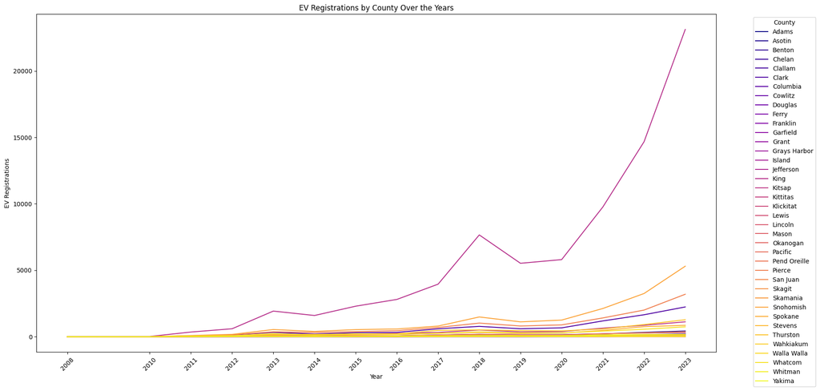

```python
# EV Registrations by County Over the Years
# Convert 'Model Year' to numeric
ev_table['Model Year'] = pd.to_numeric(ev_table['Model Year'], errors='coerce')
ev_table = ev_table[ev_table['Model Year'] >= 2008]
# Group by 'County' and 'Model Year' and count the registrations
ev_registrations = ev_table.groupby(['County', 'Model Year']).size().reset_index(name='Registrations')

# Pivot the table to have 'Model Year' as columns and 'County' as rows
ev_registrations_pivot = ev_registrations.pivot(index='County', columns='Model Year', values='Registrations').fillna(0)

# Create a colormap
colors = plt.cm.plasma(np.linspace(0, 1, len(ev_registrations_pivot.index)))

# Plot the data
plt.figure(figsize=(20, 10))
for color, county in zip(colors, ev_registrations_pivot.index):
    plt.plot(ev_registrations_pivot.columns, ev_registrations_pivot.loc[county], label=county, color=color)

plt.xlabel('Year')
plt.ylabel('EV Registrations')
plt.title('EV Registrations by County Over the Years')
plt.legend(title='County', bbox_to_anchor=(1.05, 1), loc='upper left')
plt.xticks(ev_registrations_pivot.columns, rotation=45)
plt.show()
```

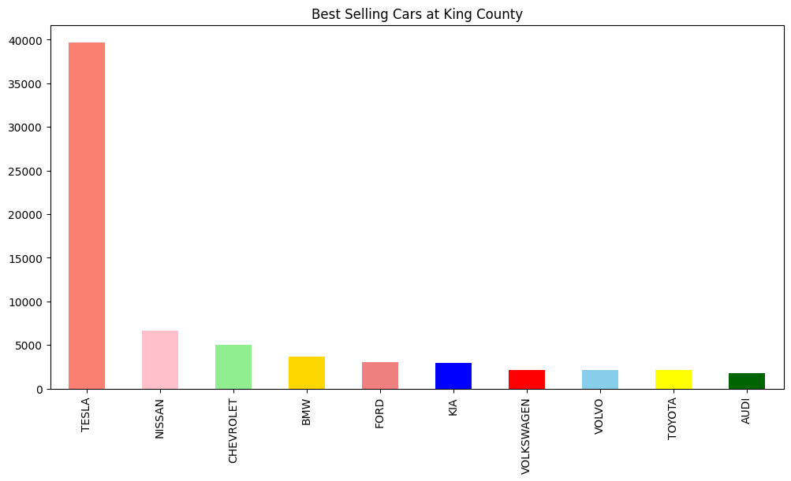

```python
king_data = ev_table[ev_table["County"] == "King"]


unique_makes = king_data["Make"].value_counts().head(10)
plt.figure(figsize=(12, 6))
unique_makes.plot(kind='bar', color = ['salmon','pink' , 'lightgreen', 'gold', 'lightcoral', 'blue', 'red', 'skyblue', 'yellow', 'darkgreen'])

plt.title('Best Selling Cars at King County')

plt.show()
```

[figure not shown]

```python
makes = ev_table["Model"].value_counts().head(5)
plt.figure(figsize=(12, 6))
makes.plot(kind='bar', color = ['gold', 'darkgreen','salmon','pink' , 'lightgreen', ])

plt.title('Best-selling electric car models in King County')
plt.show()
```

**Number of EV station**

this bar chart shoulws that the number of the EV station in each county

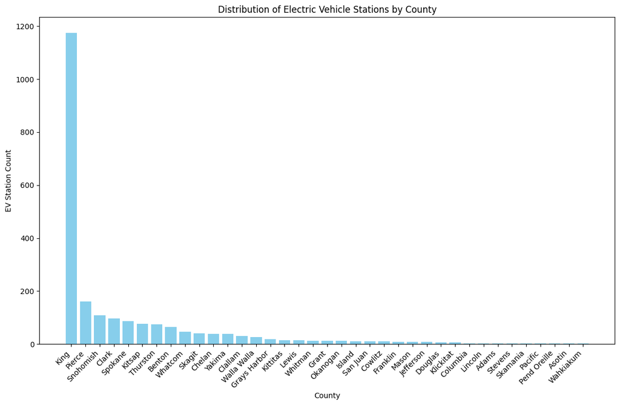

```python
# Get counts of electric vehicle stations per county
ev_station_by_county = ev_station['county'].value_counts().reset_index()
ev_station_by_county.columns = ['county', 'electric_sataions_count']
# Plot a bar chart with a specified figure size
plt.figure(figsize=(14, 8))
plt.bar(ev_station_by_county['county'], ev_station_by_county['electric_sataions_count'], color='skyblue')
plt.title('Distribution of Electric Vehicle Stations by County')
plt.xlabel('County')
plt.ylabel('EV Station Count')
plt.xticks(rotation=45, ha='right')  # Rotate x-axis labels for better readability
plt.show()
```

**Demographic table**

```python
# List of columns to convert
cols_to_convert = ['CountyId', 'TotalPop', 'Men', 'Women', 'Hispanic', 'White',
                   'Black', 'Native', 'Asian', 'Pacific', 'Income', 'Professional',
                   'Employed', 'PrivateWork', 'PublicWork', 'SelfEmployed', 'FamilyWork',
                   'Unemployment']

# Convert columns to numeric
Demographic[cols_to_convert] = Demographic[cols_to_convert].apply(pd.to_numeric, errors='coerce')
```

```python
# Normalize the data by population
for col in Demographic.columns[2:]:
    Demographic[col] = Demographic[col] / Demographic['TotalPop'] * 100

Demographic.head()
```

|  | CountyId | County | TotalPop | Men | Women | Hispanic | White | Black | Native | Asian | Pacific | Income | Professional | Employed | PrivateWork | PublicWork | SelfEmployed | FamilyWork | Unemployment |
| --- | --- | --- | --- | --- | --- | --- | --- | --- | --- | --- | --- | --- | --- | --- | --- | --- | --- | --- | --- |
| 2953 | 53001 | Adams | 100.0 | 9750.0 | 9511.0 | 62.3 | 35.2 | 0.3 | 0.4 | 1.0 | 0.0 | 48131.0 | 22.8 | 7757.0 | 81.2 | 14.6 | 3.8 | 0.3 | 5.9 |
| 2954 | 53003 | Asotin | 100.0 | 10594.0 | 11665.0 | 3.6 | 91.2 | 0.4 | 0.9 | 0.9 | 0.1 | 47483.0 | 30.0 | 9824.0 | 78.6 | 16.1 | 5.2 | 0.1 | 6.7 |
| 2955 | 53005 | Benton | 100.0 | 95438.0 | 95091.0 | 20.8 | 71.6 | 1.4 | 0.6 | 2.5 | 0.1 | 63001.0 | 39.4 | 85352.0 | 78.4 | 17.3 | 4.3 | 0.1 | 6.0 |
| 2956 | 53007 | Chelan | 100.0 | 37352.0 | 37786.0 | 27.5 | 68.3 | 0.4 | 0.9 | 0.9 | 0.1 | 54975.0 | 30.4 | 34063.0 | 76.2 | 16.2 | 7.4 | 0.2 | 5.8 |
| 2957 | 53009 | Clallam | 100.0 | 36389.0 | 37050.0 | 6.0 | 83.3 | 1.1 | 4.4 | 1.5 | 0.1 | 48002.0 | 30.2 | 28027.0 | 68.4 | 22.9 | 8.6 | 0.2 | 8.8 |

Next, I will proceed by merging all the tables into a single consolidated dataset.

```python
# Merge the datasets based on county
merged_data = pd.merge(ev_by_county, ev_station_by_county, left_on="County", right_on="county")
merged_data = merged_data.merge(Demographic, on='County')
# Assuming 'merged_data' is your dataframe and 'county' is the column you want to drop
merged_data = merged_data.drop('county', axis=1)

merged_data.head()
```

|  | County | electric_vehicle_count | electric_sataions_count | CountyId | TotalPop | Men | Women | Hispanic | White | Black | ... | Asian | Pacific | Income | Professional | Employed | PrivateWork | PublicWork | SelfEmployed | FamilyWork | Unemployment |
| --- | --- | --- | --- | --- | --- | --- | --- | --- | --- | --- | --- | --- | --- | --- | --- | --- | --- | --- | --- | --- | --- |
| 0 | King | 80069 | 1175 | 53033 | 100.0 | 1058695.0 | 1059424.0 | 9.5 | 61.4 | 6.0 | ... | 16.5 | 0.8 | 83571.0 | 51.0 | 1140353.0 | 82.0 | 12.0 | 5.8 | 0.2 | 5.0 |
| 1 | Snohomish | 17589 | 108 | 53061 | 100.0 | 387078.0 | 384826.0 | 9.8 | 71.2 | 2.6 | ... | 9.9 | 0.5 | 78020.0 | 38.9 | 390186.0 | 81.9 | 12.5 | 5.4 | 0.2 | 5.4 |
| 2 | Pierce | 11708 | 160 | 53053 | 100.0 | 420170.0 | 425023.0 | 10.4 | 68.0 | 6.5 | ... | 6.0 | 1.4 | 63881.0 | 33.9 | 383286.0 | 76.7 | 18.5 | 4.6 | 0.1 | 6.9 |
| 3 | Clark | 8993 | 96 | 53011 | 100.0 | 226178.0 | 231296.0 | 9.0 | 79.4 | 1.8 | ... | 4.4 | 0.7 | 67832.0 | 36.3 | 213776.0 | 80.5 | 13.4 | 5.9 | 0.2 | 6.2 |
| 4 | Thurston | 5488 | 74 | 53067 | 100.0 | 132099.0 | 137786.0 | 8.5 | 75.8 | 2.8 | ... | 5.6 | 0.8 | 66113.0 | 41.9 | 122976.0 | 63.9 | 29.9 | 5.9 | 0.2 | 7.7 |

5 rows × 21 columns

**EV count with income**

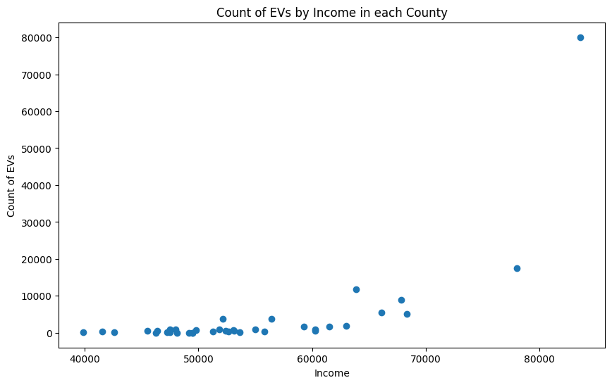

```python
# Extract income and electric vehicle count data
income_data = merged_data['Income']
ev_count = merged_data['electric_vehicle_count']

# Create the scatter plot
plt.figure(figsize=(10, 6))
plt.scatter(income_data, ev_count)
plt.xlabel("Income")
plt.ylabel("Count of EVs")
plt.title("Count of EVs by Income in each County")
plt.show()
```

This plot that I can find that at the lower of the income scale but with a significant outlier that shows a very high number of EVs at a higher income level.

And I will apply a log scale to normalize the distribution, which may help in uncovering any underlying trends.

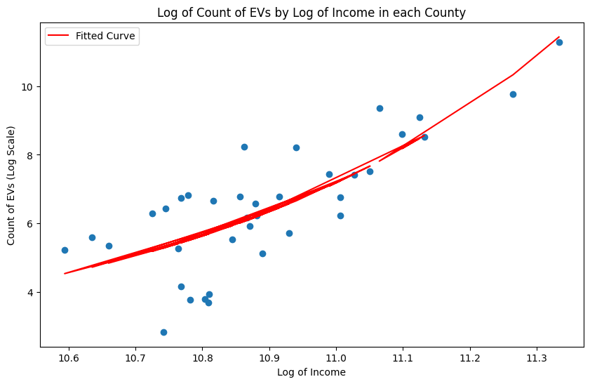

```python
# Apply a logarithmic transformation to the data
log_income_data = np.log(income_data)
log_ev_count = np.log(ev_count)

# Define a function for the curve fit
def model_func(x, a, b, c):
  return a * np.exp(b * x) + c

# Fit the curve to the data with increased maxfev and adjusted initial guess
popt, pcov = curve_fit(model_func, log_income_data, log_ev_count, p0=[1, 0, 1], maxfev=5000)

# Generate fitted curve data
fitted_curve = model_func(log_income_data, *popt)

# Create the scatter plot for the transformed data
plt.figure(figsize=(10, 6))
plt.scatter(log_income_data, log_ev_count)
plt.plot(log_income_data, fitted_curve, "r-", label="Fitted Curve")
plt.xlabel("Log of Income")
plt.ylabel("Count of EVs (Log Scale)")
plt.title("Log of Count of EVs by Log of Income in each County")
plt.legend()
plt.show()
```

Now we can find following information:

Positive Correlation: The fitted curve is upward-sloping, indicating a positive correlation on the log-log scale. This means that as income increases, the number of EVs tends to increase as well.

Log-Log Transformation: Using a log scale for both the income and EV count can help linearize exponential relationships. This suggests that the relationship between income and EV count might be multiplicative rather than additive.

## Model

- Idea 1: EV Adpotion prodicet

  suggests a non-linear relationship between county income and EV count. This suggests that a model based on exponential growth might be suitable.

  Model equation:

  EV Count = a * exp(b * Income) + c where:

  EV Count: The number of electric vehicles in a county. Income: The average income in a county (logarithm transformed). a, b, c: Model parameters to be estimated. Parameter estimation:

  The parameters a, b, and c can be estimated using curve fitting techniques like the Levenberg-Marquardt algorithm. This involves minimizing the sum of squared errors between the predicted and actual EV counts.

  Model interpretation:

  The estimated parameters provide insights into the relationship between income and EV count.

  a: This represents the baseline EV count in a county with zero income. b: This represents the exponential growth rate of EV count with increasing income. A positive b value indicates that the EV count increases exponentially with income. c: This represents the error term in the model.

```python
# Calculate the Pearson Correlation Coefficient
correlation = income_data.corr(ev_count)
print(f"Pearson Correlation Coefficient between income and count of EVs: {correlation:.4f}")
```

```
Pearson Correlation Coefficient between income and count of EVs: 0.6720
```

```python
# Print the estimated parameters
a, b, c = popt
print(f"Estimated parameters: a={a:.4f}, b={b:.4f}, c={c:.4f}")
```

```
Estimated parameters: a=0.0000, b=1.8402, c=2.1518
```

Let me apply the K-Neighbors Regression method to predict and analyze the data.

```python
from sklearn.neighbors import KNeighborsRegressor

# Selecting features and target variable
features = ['Income','electric_sataions_count', 'Hispanic', 'White', 'Black', 'Native', 'Asian', 'Pacific',
            'Professional', 'Employed', 'PrivateWork', 'PublicWork', 'SelfEmployed', 'FamilyWork', 'Unemployment'
            ]
target = 'electric_vehicle_count'

# Standardizing the features
scaler = StandardScaler()
merged_data[features] = scaler.fit_transform(merged_data[features])

# Use the scaled variable as the target
X = merged_data[features]
y = merged_data[target]

# Change the model to KNeighborsRegressor
knn_reg = KNeighborsRegressor(n_neighbors=5)

# Define the MAE scorer
mae_scorer = make_scorer(mean_absolute_error)

# Perform 5-fold cross-validation and compute the MAE
mae_scores = cross_val_score(knn_reg, X, y, scoring=mae_scorer, cv=6)

# Print the results
print("MAE scores for each fold are:", mae_scores)
print("Mean MAE score:", np.mean(mae_scores))

# Split the data into a training set and a test set
X_train, X_test, y_train, y_test = train_test_split(X, y, test_size=0.2, random_state=42)

# Train the model on the training set
knn_reg.fit(X_train, y_train)

# Make predictions on the test set
y_pred = knn_reg.predict(X_test)

# Calculate R^2 score
r2 = r2_score(y_test, y_pred)
print(f"R^2 score: {r2:.4f}")
```

```
MAE scores for each fold are: [17247.37142857  1122.3          461.1          577.76666667
  1332.96666667   733.6       ]
Mean MAE score: 3579.1841269841266
R^2 score: 0.7569
```

An $R^2$ of 0.7569 is relatively high, indicating a good level of fit to the data. This suggests that the model is capturing a significant portion of the variance in the dataset.

- Idea 2: EV recommendations using K-Means Clustering

```python
# Define the features to be used for clustering
features_for_clustering = ['Income', 'Employed']

# Create a copy of the selected features from the merged data
data_for_clustering = merged_data[features_for_clustering].copy()

# Fill any missing values with 0
data_for_clustering.fillna(0, inplace=True)

# Initialize a StandardScaler instance
scaler = StandardScaler()

# Fit the scaler to the data and transform it
scaled_features = scaler.fit_transform(data_for_clustering)

# Initialize a KMeans instance
kmeans_model = KMeans(n_clusters=2, n_init=10, random_state=42)

# Fit the KMeans model to the data and predict the clusters
predicted_clusters = kmeans_model.fit_predict(scaled_features)

# Add the predicted cluster labels to the original merged data
merged_data['ClusterLabel'] = predicted_clusters
```

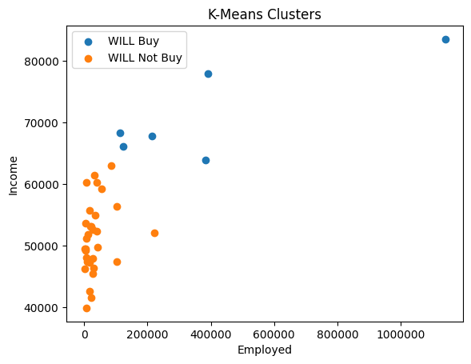

```python
# Plotting each cluster
fig, ax = plt.subplots()

cluster_labels = {1: 'WILL Buy', 0: 'WILL Not Buy'}
for cluster in merged_data['ClusterLabel'].unique():
    cluster_data = merged_data[merged_data['ClusterLabel'] == cluster]
    ax.scatter(cluster_data['Employed'], cluster_data['Income'], label=cluster_labels[cluster])

# Use ticklabel_format to avoid scientific notation
ax.ticklabel_format(style='plain', axis='y', useOffset=False)
ax.ticklabel_format(style='plain', axis='x', useOffset=False)

ax.set_xlabel('Employed')
ax.set_ylabel('Income')
ax.set_title('K-Means Clusters')
ax.legend()

plt.show()
```

Here’s what I can interpret from the graph:

Income: The y-axis represents the income of individuals. It appears that those in the "WILL Buy" cluster generally have a higher income range compared to the majority of those in the "WILL Not Buy".

**Comclutoion for this project**

```
It's important to note that this is a simplified visualization, and the real-world decision to purchase an EV can be influenced by many factors beyond income and employment rates. For a more comprehensive analysis, other variables such as environmental awareness, vehicle preferences, and government incentives should also be considered.
```

```python
# Convert Jupyter notebook to HTML
!jupyter nbconvert --to html project.ipynb
```

```
[NbConvertApp] Converting notebook project.ipynb to html
[NbConvertApp] WARNING | Alternative text is missing on 8 image(s).
[NbConvertApp] Writing 873497 bytes to project.html
```